[figure not shown]

# Analyse des correspondances multiples (ACM)

Ce chapitre est évoqué dans le webin-R #11 (Analyse des Correspondances Multiples sur [YouTube](https://youtu.be/fIZblrfenz0).

Il existe plusieurs techniques d’analyse factorielle dont les plus courantes sont l’analyse en composante principale (ACP) portant sur des variables quantitatives, l’analyse factorielle des correspondances (AFC) portant sur deux variables qualitatives et l’analyse des correspondances multiples (ACM) portant sur plusieurs variables qualitatives (il s’agit d’une extension de l’AFC). Pour combiner des variables à la fois quantitatives et qualitatives, on pourra avoir recours à l’analyse factorielle avec données mixtes.

Bien que ces techniques soient disponibles dans les extensions standards de **R**, il est souvent préférable d’avoir recours à deux autres extensions plus complètes, `ade4` et `FactoMineR`, chacune ayant ses avantages et des possibilités différentes. Voici les fonctions les plus fréquentes :

| Analyse | Variables | Fonction standard | Fonction `ade4` | Fonctions `FactoMineR` |
| --- | --- | --- | --- | --- |
| ACP | plusieurs variables quantitatives | `princomp` | `dudi.pca` | `PCA` |
| AFC | deux variables qualitatives | `corresp` | `dudi.coa` | `CA` |
| ACM | plusieurs variables qualitatives | `mca` | `dudi.acm` | `MCA` |
| Analyse mixte | plusieurs variables quantitatives et/ou qualitatives | — | `dudi.mix` | `FAMD` |

Dans la suite de ce chapitre, nous n’arboderons que l’analyse des correspondances multiples (ACM).

On trouvera également de nombreux supports de cours en français sur l’analyse factorielle sur le site de François Gilles Carpentier : http://geai.univ-brest.fr/~carpenti/.

## Principe général

L’analyse des correspondances multiples est une technique descriptive visant à résumer l’information contenu dans un grand nombre de variables afin de faciliter l’interprétention des corrélations existantes entre ces différentes variables. On cherche à savoir quelles sont les modalités corrélées entre elles.

L’idée générale est la suivante[^1]. L’ensemble des individus peut être représenté dans un espace à plusieurs dimensions où chaque axe représente les différentes variables utilisées pour décrire chaque individu. Plus précisément, pour chaque variable qualitative, il y a autant d’axes que de modalités moins un. Ainsi il faut trois axes pour décrire une variable à quatre modalités. Un tel nuage de points est aussi difficile à interpréter que de lire directement le fichier de données. On ne voit pas les corrélations qu’il peut y avoir entre modalités, par exemple qu’aller au cinéma est plus fréquent chez les personnes habitant en milieu urbain. Afin de mieux représenter ce nuage de points, on va procéder à un changement de systèmes de coordonnées. Les individus seront dès lors projetés et représentés sur un nouveau système d’axe. Ce nouveau système d’axes est choisis de telle manière que la majorité des variations soit concentrées sur les premiers axes. Les deux-trois premiers axes permettront d’expliquer la majorité des différences observées dans l’échantillon, les autres axes n’apportant qu’une faible part additionnelle d’information. Dès lors, l’analyse pourra se concentrer sur ses premiers axes qui constitueront un bon résumé des variations observables dans l’échantillon.

Avant toute ACM, il est indispensable de réaliser une analyse préliminaire de chaque variable, afin de voir si toutes les classes sont aussi bien représentées ou s’il existe un déséquilibre. L’ACM est sensible aux effectifs faibles, aussi il est préférable de regrouper les classes peu représentées le cas échéant.

## ACM avec ade4

Si l’extension `ade4` n’est pas présente sur votre PC, il vous faut l’installer :

```r
install.packages("ade4", dep = TRUE)
```

Dans tous les cas, il faut penser à la charger en mémoire :

```r
library(ade4)
```

Comme précédemment, nous utiliserons le fichier de données `hdv2003` fourni avec l’extension `questionr`.

```r
library(questionr)
data(hdv2003)
d <- hdv2003
```

En premier lieu, comme dans le chapitre sur la régression logistique, nous allons créer une variable groupe d’âges et regrouper les modalités de la variable « niveau d’étude ».

```r
d$grpage <- cut(d$age, c(16, 25, 45, 65, 93), right = FALSE, include.lowest = TRUE)
d$etud <- d$nivetud
levels(d$etud) <- c(
  "Primaire", "Primaire", "Primaire", "Secondaire", "Secondaire",
  "Technique/Professionnel", "Technique/Professionnel", "Supérieur"
)
```

Ensuite, nous allons créer un tableau de données ne contenant que les variables que nous souhaitons prendre en compte pour notre analyse factorielle.

```r
d2 <- d[, c("grpage", "sexe", "etud", "peche.chasse", "cinema", "cuisine", "bricol", "sport", "lecture.bd")]
```

Le calcul de l’ACM se fait tout simplement avec la fonction `dudi.acm`.

```r
acm <- dudi.acm(d2)
```

Par défaut, la fonction affichera le graphique des valeurs propres de chaque axe (nous y reviendrons) et vous demandera le nombre d’axes que vous souhaitez conserver dans les résultats. Le plus souvent, cinq axes seront largement plus que suffisants. Vous pouvez également éviter cette étape en indiquant directement à `dudi.acm` de vous renvoyer les cinq premiers axes ainsi :

```r
acm <- dudi.acm(d2, scannf = FALSE, nf = 5)
```

Si vous souhaitez explorer visuellement et interacticement les résultats, vous pouvez utiliser l’extension `explor` et sa fonction homonyme `explor`.

```r
explor::explor(acm)
```

Le graphique des valeurs propres peut être reproduit avec `screeplot` :

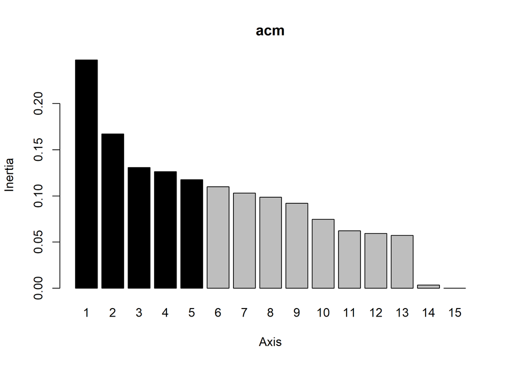

Valeurs propres ou inertie de chaque axe avec screeplot()

```r
screeplot(acm)
```

Pour des grahiques reposant sur `ggplot2`, on pourra avoir recours à l’extension `factoextra` qui fournit plusieurs fonctions graphiques dont `fviz_screeplot`

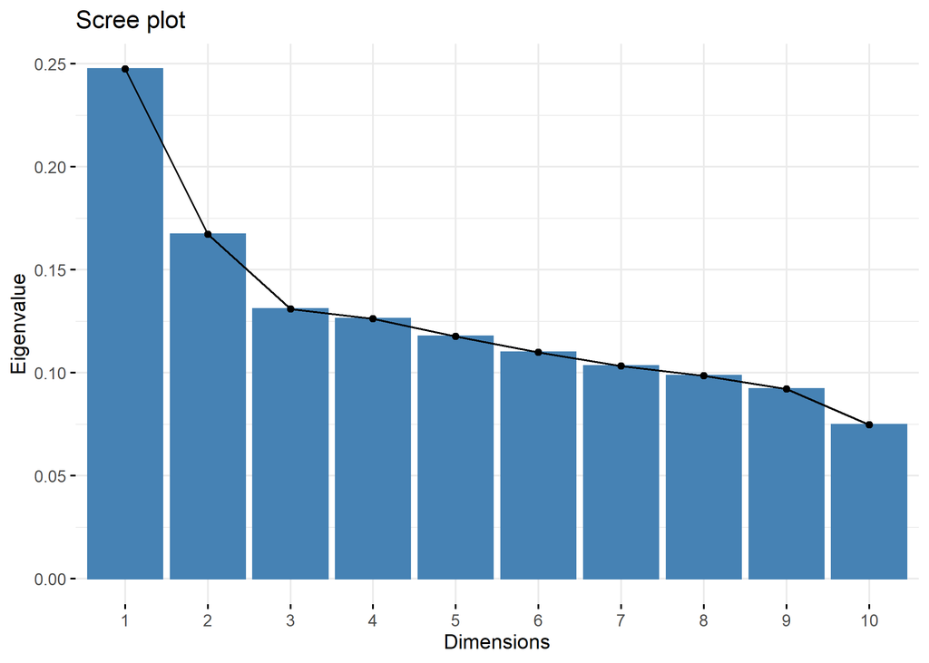

Valeurs propres des axe avec fviz_screeplot()

```r
library(factoextra)
fviz_screeplot(acm, choice = "eigenvalue")
```

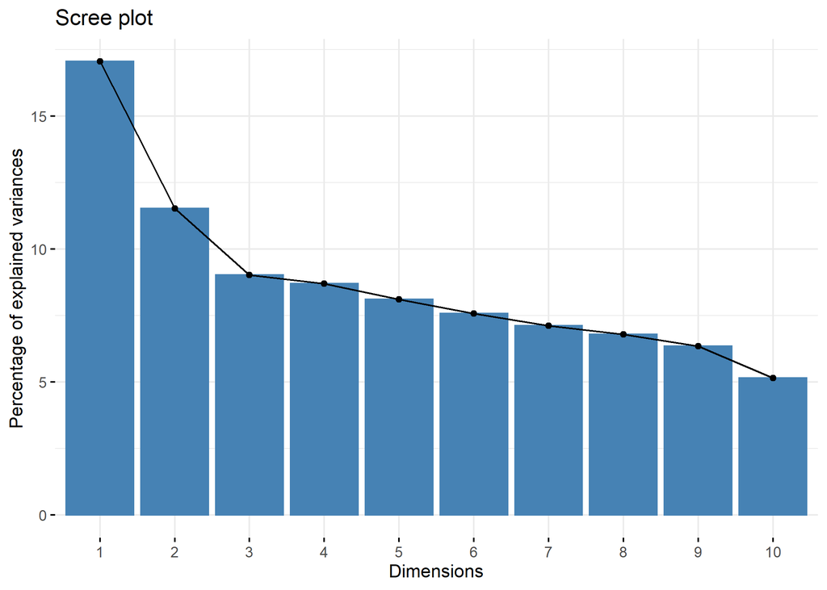

Pourcentage de variance expliquée avec fviz_screeplot()

```r
library(factoextra)
fviz_screeplot(acm)
```

Les mêmes valeurs pour les premiers axes s’obtiennent également avec `summary`. On pourra également avoir recours à la fonction `inertia.dudi` pour l’ensemble des axes.

```r
summary(acm)
```

```
Class: acm dudi
Call: dudi.acm(df = d2, scannf = FALSE, nf = 5)

Total inertia: 1.451

Eigenvalues:
    Ax1     Ax2     Ax3     Ax4     Ax5
 0.2474  0.1672  0.1309  0.1263  0.1176

Projected inertia (%):
    Ax1     Ax2     Ax3     Ax4     Ax5
 17.055  11.525   9.022   8.705   8.109

Cumulative projected inertia (%):
    Ax1   Ax1:2   Ax1:3   Ax1:4   Ax1:5
  17.06   28.58   37.60   46.31   54.42

(Only 5 dimensions (out of 15) are shown)
```

```r
inertia.dudi(acm)
```

```
Inertia information:
Call: inertia.dudi(x = acm)

Decomposition of total inertia:
       inertia     cum  cum(%)
Ax1  0.2474360  0.2474   17.06
Ax2  0.1671951  0.4146   28.58
Ax3  0.1308832  0.5455   37.60
Ax4  0.1262915  0.6718   46.31
Ax5  0.1176380  0.7894   54.42
Ax6  0.1099985  0.8994   62.00
Ax7  0.1032282  1.0027   69.11
Ax8  0.0986748  1.1013   75.91
Ax9  0.0920695  1.1934   82.26
Ax10 0.0747282  1.2681   87.41
Ax11 0.0623488  1.3305   91.71
Ax12 0.0593251  1.3898   95.80
Ax13 0.0573240  1.4471   99.75
Ax14 0.0035264  1.4507   99.99
Ax15 0.0001104  1.4508  100.00
```

Pour comprendre la signification des différents axes, il importe d’identifier quelles sont les variables/ modalités qui contribuent le plus à chaque axe. Une première représentation graphique est le cercle de corrélation des modalités. Pour cela, on aura recours à `s.corcicle`. On indiquera d’abord `acm$co` si l’on souhaite représenter les modalités ou `acm$li` si l’on souhaite représenter les individus. Les deux chiffres suivant indiquent les deux axes que l’on souhaite afficher (dans le cas présent les deux premiers axes). Enfin, le paramètre `clabel` permet de modifier la taille des étiquettes.

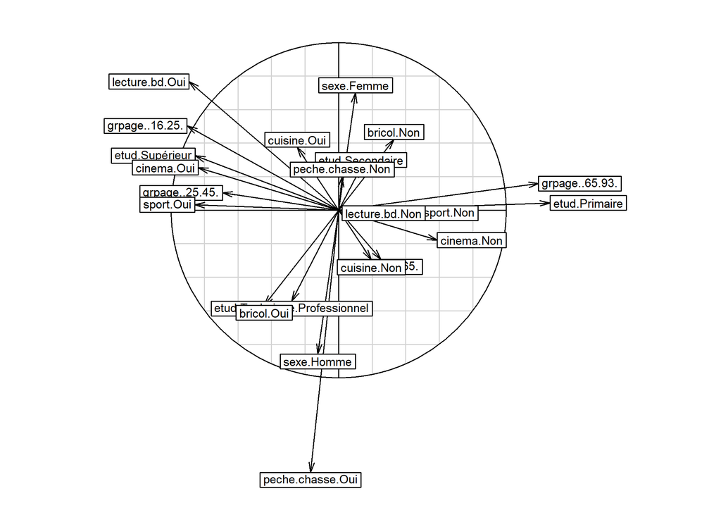

Cercle de corrélations des modalités sur les deux premiers axes

```r
s.corcircle(acm$co, 1, 2, clabel = 0.7)
```

Il est aussi possible d’utiliser `fviz_mca_var` de `factoextra`. L’option `repel = TRUE` permets d’éviter que les étiquettes ne se superposent.

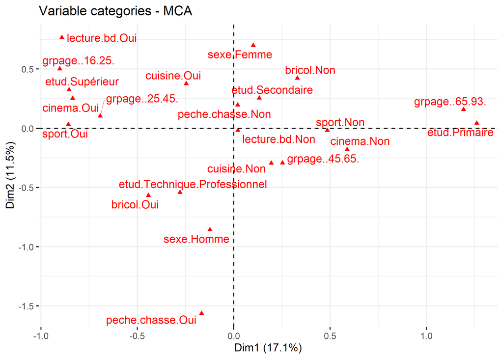

Représentation des modalités sur les deux premiers axes

```r
fviz_mca_var(acm, repel = TRUE)
```

On pourra avoir également recours à `boxplot` pour visualiser comment se répartissent les modalités de chaque variable sur un axe donné[^2].

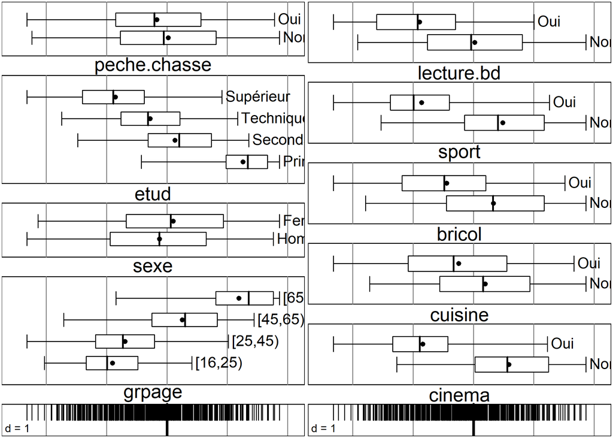

Répartition des modalités selon le premier axe

```r
boxplot(acm)
```

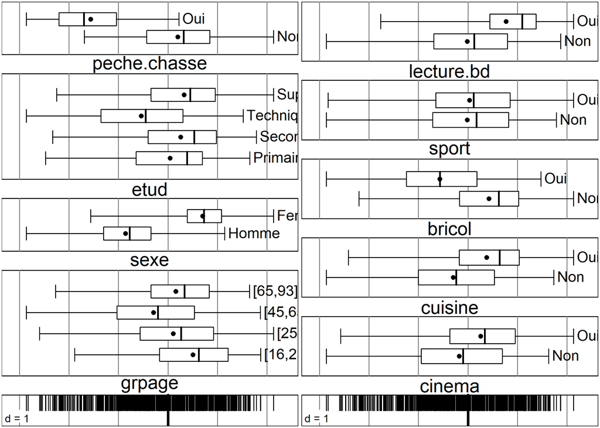

Répartition des modalités selon le second axe

```r
boxplot(acm, 2)
```

La fonction `fviz_contrib` de `factoextra` peut être utilisée pour représenter la contribution des différentes variables sur un axe.

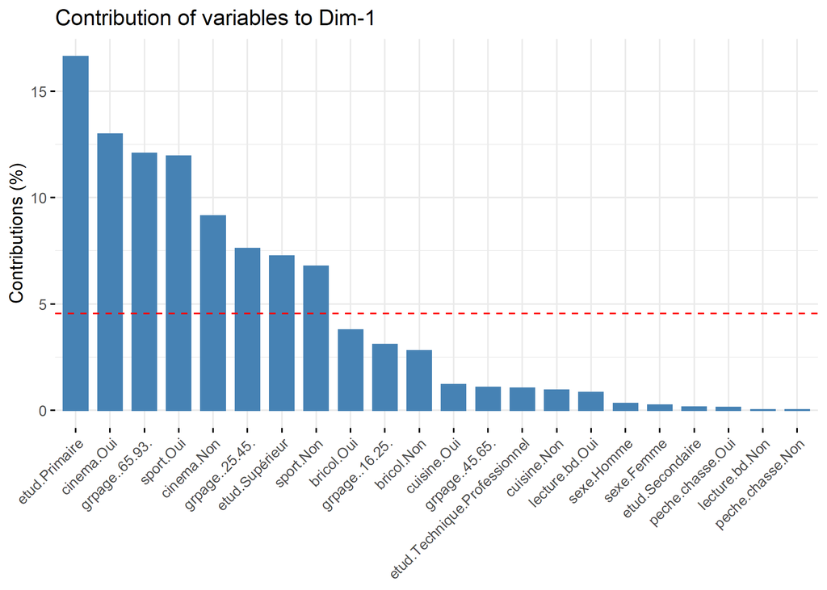

```r
fviz_contrib(acm, choice = "var", axes = 1)
```

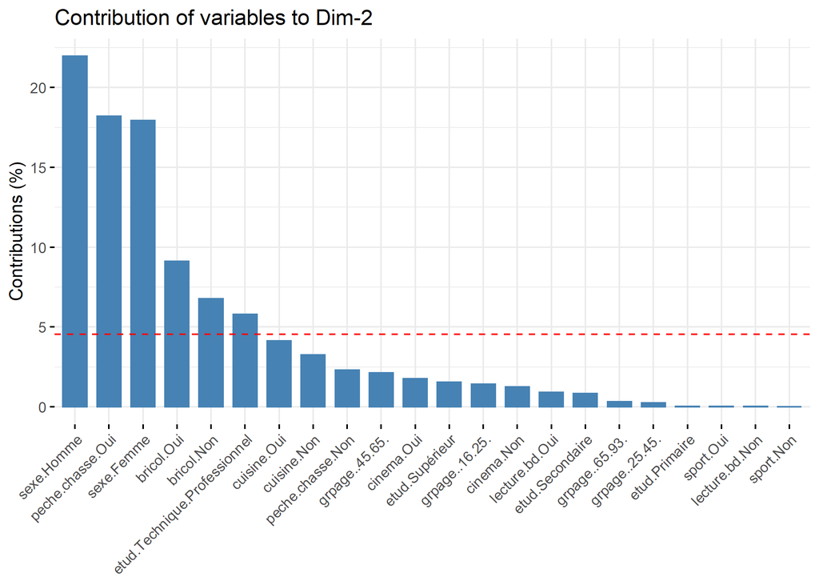

Représentation de la contribution des différentes variables

```r
fviz_contrib(acm, choice = "var", axes = 2)
```

Le tableau `acm$cr` contient les rapports de corrélation (variant de 0 à 1) entre les variables et les axes choisis au départ de l’ACM. Pour représenter graphiquement ces rapports, utiliser la fonction `barplot` ainsi : `barplot(acm$cr[,num],names.arg=row.names( acm$cr),las=2)` où `num` est le numéro de l’axe à représenter. Pour l’interprétation des axes, se concentrer sur les variables les plus structurantes, c’est-à-dire dont le rapport de corrélation est le plus proche de 1.

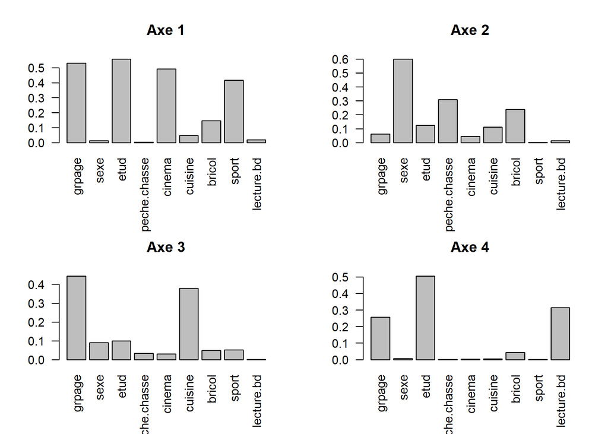

```r
par(mfrow = c(2, 2))
for (i in 1:4) barplot(acm$cr[, i], names.arg = row.names(acm$cr), las = 2, main = paste("Axe", i))
```

```r
par(mfrow = c(1, 1))
```

Rapports de corrélation des variables sur les 4 premiers axes

Le paramètre `mfrow` de la fonction `par` permet d’indiquer à **R** que l’on souhaite afficher plusieurs graphiques sur une seule et même fenêtre, plus précisément que l’on souhaite diviser la fenêtre en deux lignes et deux colonnes.

Dans l’exemple précédent, après avoir produit notre graphique, nous avons réinitilisé cette valeur à `c(1, 1)` (un seul graphique par fenêtre) pour ne pas affecter les prochains graphiques que nous allons produire.

Pour représenter, les modalités dans le plan factoriel, on utilisera la fonction `s.label`. Par défaut, les deux premiers axes sont représentés.

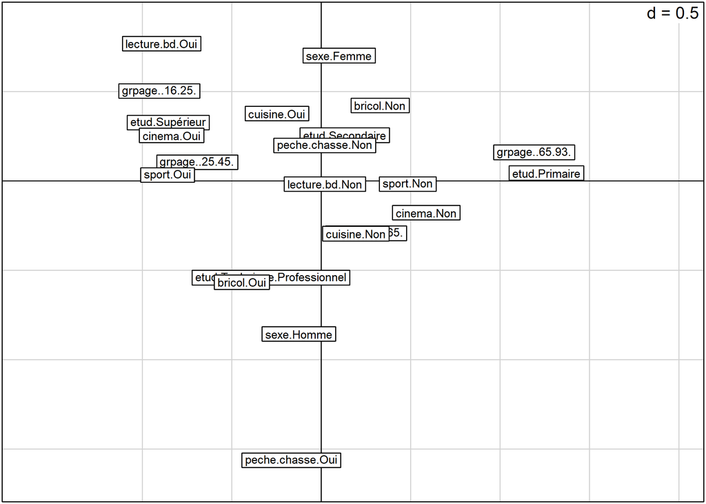

Répartition des modalités selon les deux premiers axes

```r
s.label(acm$co, clabel = 0.7)
```

Il est bien sur possible de préciser les axes à représenter. L’argument `boxes` permet quant à lui d’indiquer si l’on souhaite tracer une boîte pour chaque modalité.

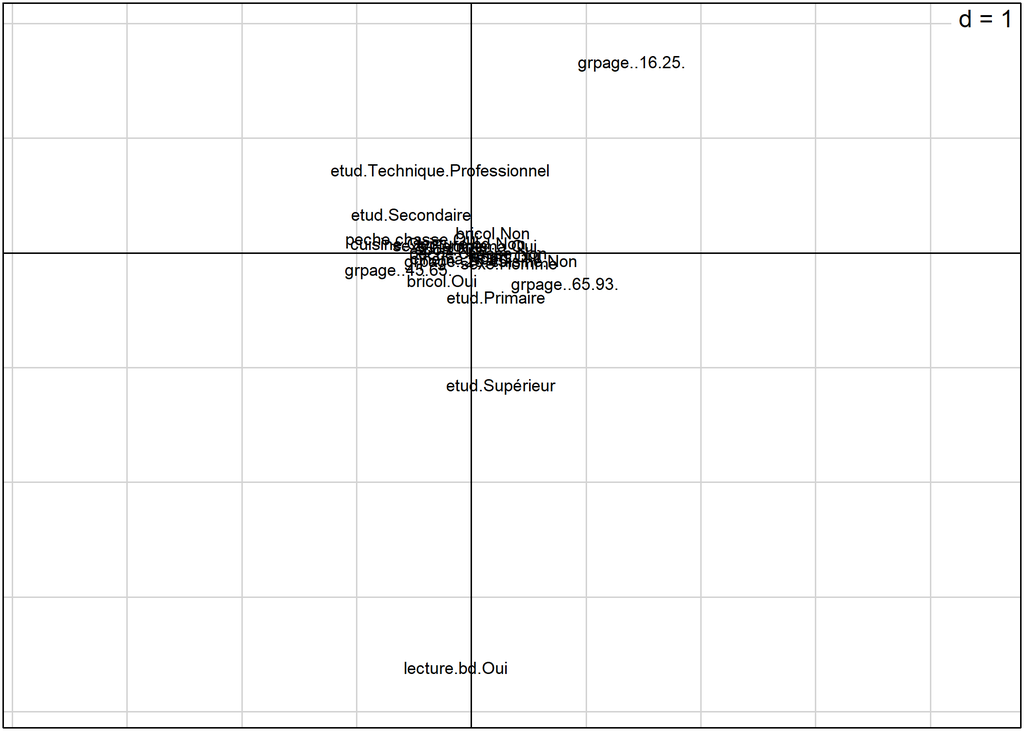

Répartition des modalités selon les axes 3 et 4

```r
s.label(acm$co, 3, 4, clabel = 0.7, boxes = FALSE)
```

Bien entendu, on peut également représenter les individus. En indiquant `clabel=0` (une taille nulle pour les étiquettes), `s.label` remplace chaque observation par un symbole qui peut être spécifié avec `pch`.

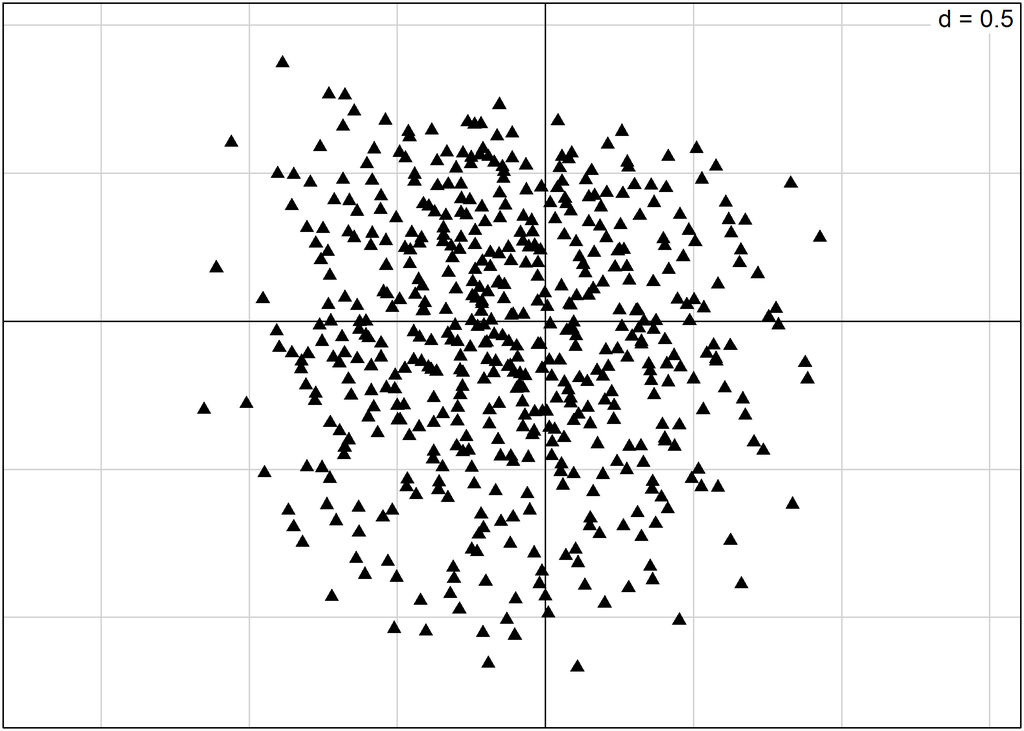

Répartition des individus selon les deux premiers axes

```r
s.label(acm$li, clabel = 0, pch = 17)
```

L’agument `pch` permet de spécifier le symbole à utiliser. Il peut prendre soit un nombre entier compris entre 0 et 25, soit un charactère textuel.

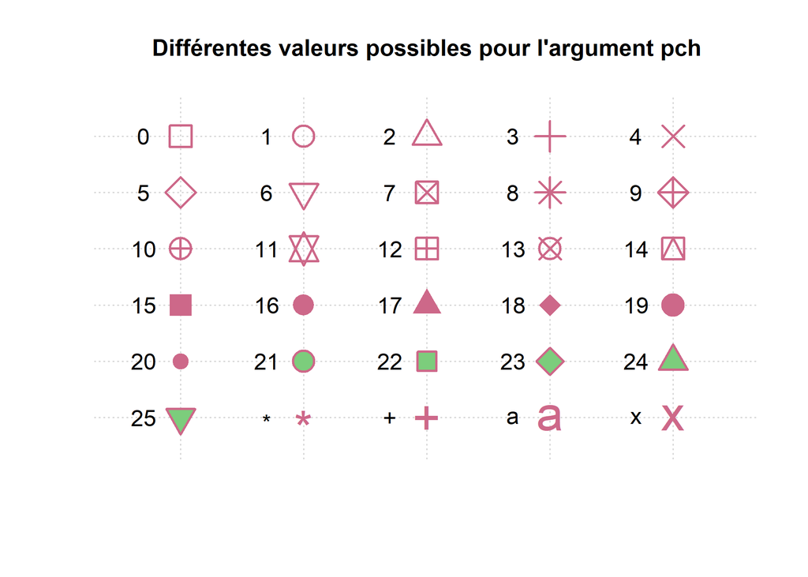

Il est également possible d’avoir recours à `fviz_mca_ind` de `factoextra`. `geom = "point"` permets de de ne réprésenter que les points sans leur étiquette. `alpha.ind = .25` permets d’appliquer une transparance.

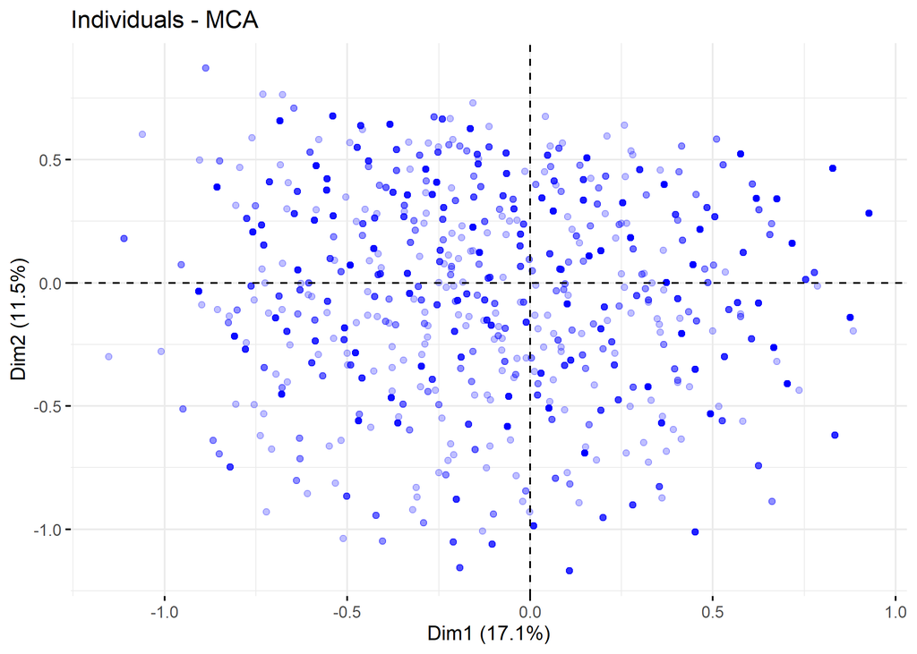

Répartition des individus selon les deux premiers axes avec fviz_mca_ind()

```r
fviz_mca_ind(acm, geom = "point", alpha.ind = .25)
```

Lorsque l’on réalise une ACM, il n’est pas rare que plusieurs observations soient identiques, c’est-à-dire correspondent à la même combinaison de modalités. Dès lors, ces observations seront projetées sur le même point dans le plan factoriel. Une représentation classique des observations avec `s.label` ne permettra pas de rendre compte les effectifs de chaque point.

Le package `JLutils`, disponible seulement sur **[GitHub](https://github.com/larmarange/JLutils)**, propose une fonction `s.freq` représentant chaque point par un carré proportionnel au nombre d’individus.

Pour installer `JLutils`, on aura recours au package `devtools` et à sa fonction `install_github` :

```r
library(devtools)
install_github("larmarange/JLutils")
```

La fonction `s.freq` s’emploie de manière similaire aux autres fonctions graphiques de `ade4`. Le paramètre `csize` permet d’ajuster la taille des carrés.

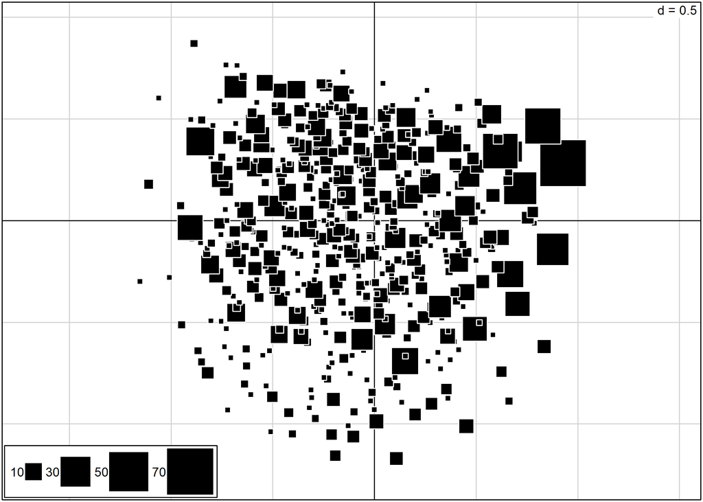

```r
library(JLutils)
s.freq(acm$li)
```

L’interprétation est tout autre, non ?

Gaston Sanchez propose un graphique amélioré des modalités dans le plan factoriel, avec notamment de coubes de densité, à cette adresse : http://rpubs.com/gaston/MCA.

La fonction `s.value` permet notamment de représenter un troisième axe factoriel. Dans l’exemple ci-après, nous projettons les individus selon les deux premiers axes factoriels. La taille et la couleur des carrés dépendent pour leur part de la coordonnée des individus sur le troisième axe factoriel. Le paramètre `csi` permet d’ajuster la taille des carrés.

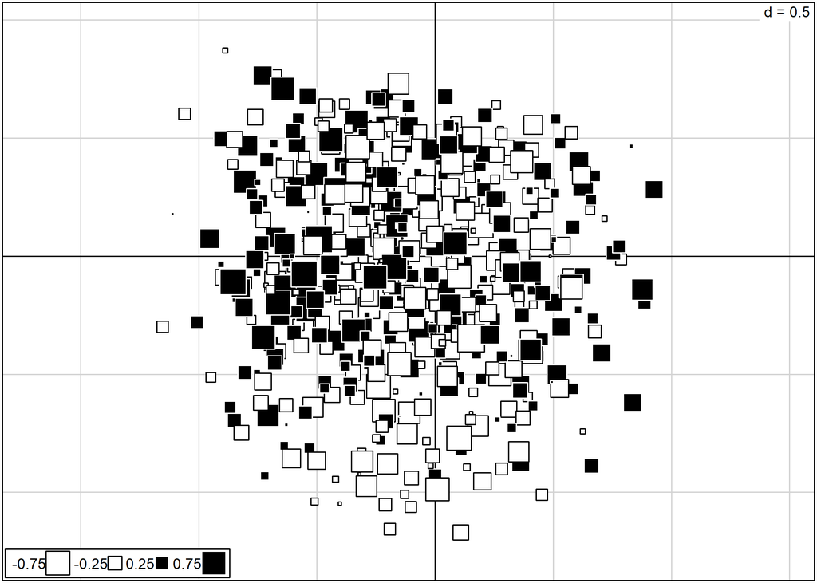

Répartition des individus selon les trois premiers axes

```r
s.value(acm$li, acm$li[, 3], 1, 2, csi = 0.5)
```

`s.arrow` permet de représenter les vecteurs variables ou les vecteurs individus sous la forme d’une flèche allant de l’origine du plan factoriel aux coordonnées des variables/individus :

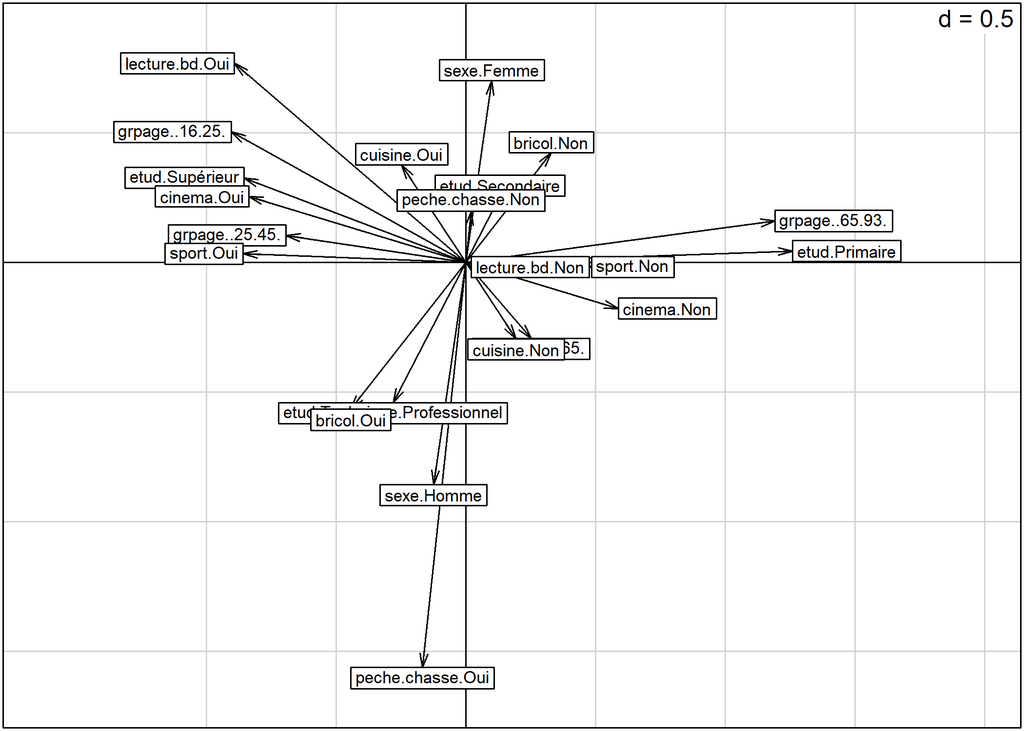

Vecteurs des modalités selon les deux premiers axes

```r
s.arrow(acm$co, clabel = 0.7)
```

`s.hist` permet de représenter des individus (ou des modalités) sur le plan factoriel et d’afficher leur distribution sur chaque axe :

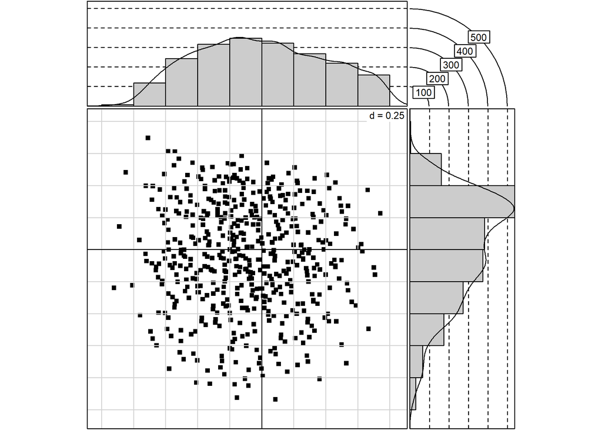

Distribution des individus dans le plan factoriel

```r
s.hist(acm$li, clabel = 0, pch = 15)
```

`s.class` et `s.chull` permettent de représenter les différentes observations classées en plusieurs catégories. Cela permet notamment de projeter certaines variables.

`s.class` représente les observations par des points, lie chaque observation au barycentre de la modalité à laquelle elle appartient et dessine une ellipse représentant la forme générale du nuage de points :

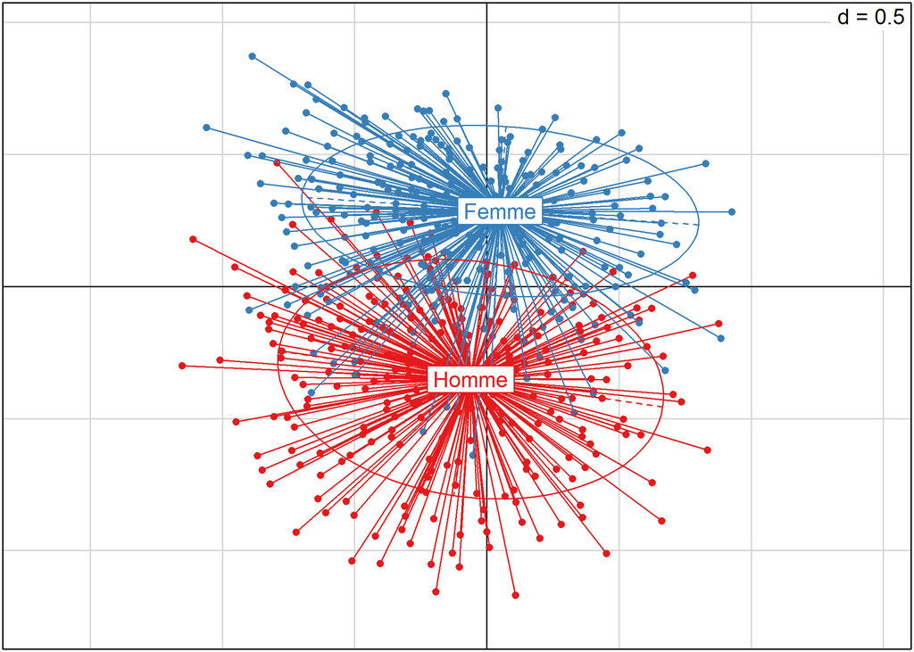

Individus dans le plan factoriel selon le sexe (s.class)

```r
library(RColorBrewer)
s.class(acm$li, d2$sexe, col = brewer.pal(4, "Set1"))
```

`s.chull` représente les barycentres de chaque catégorie et dessine des lignes de niveaux représentant la distribution des individus de cette catégorie. Les individus ne sont pas directement représentés :

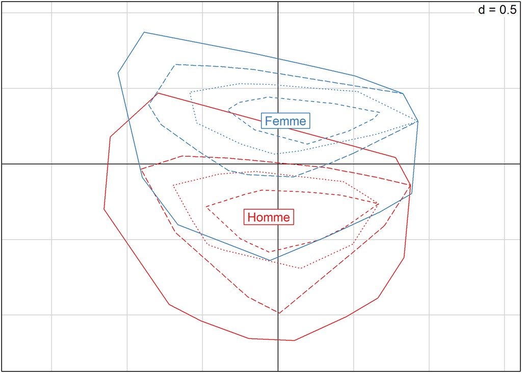

Individus dans le plan factoriel selon le sexe (s.chull)

```r
s.chull(acm$li, d2$sexe, col = brewer.pal(4, "Set1"))
```

Il est préférable de fournir une liste de couleurs (via le paramètre `col`) pour rendre le graphique plus lisible. Si vous avez installé l’extension `RColorBrewer`, vous pouvez utiliser les différentes palettes de couleurs proposées. Pour afficher les palettes disponibles, utilisez `display.brewer.all`.

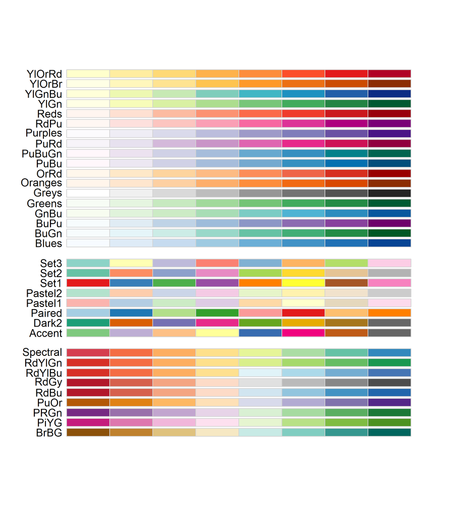

```r
library(RColorBrewer)
display.brewer.all(8)
```

Pour obtenir une palette de couleurs, utilisez la fonction `brewer.pal` avec les arguments `n` (nombre de couleurs demandées) et `pal`(nom de la palette de couleurs désirée).

Pour plus d’informations sur les palettes de couleurs de **R**, voir le chapitre dédié.

Il est aussi possible de passer à `fviz_mca_ind` une variable de regroupement via le paramètre `habillage`.

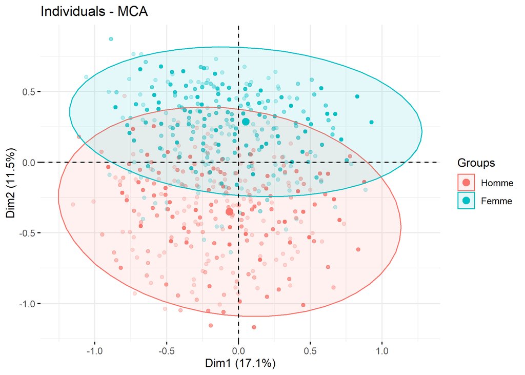

Individus dans le plan factoriel selon le sexe (fviz_mca_ind)

```r
fviz_mca_ind(acm, geom = "point", alpha.ind = .25, habillage = d2$sexe, addEllipses = TRUE)
```

La variable catégorielle transmise à `s.class` ou `s.chull` n’est pas obligatoirement une des variables retenues pour l’ACM. Il est tout à fait possible d’utiliser une autre variable. Par exemple :

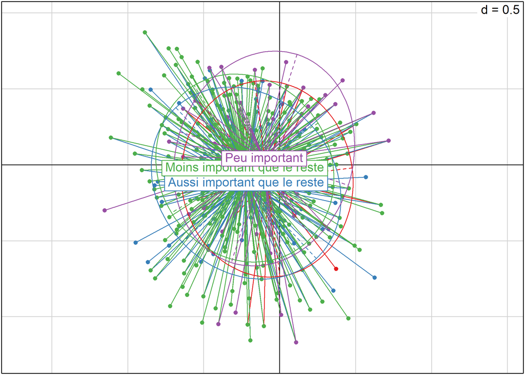

Individus dans le plan factoriel selon l’importance donnée au travail

```r
s.class(acm$li, d$trav.imp, col = brewer.pal(4, "Set1"))
```

Les fonctions `scatter` et `biplot` sont équivalentes : elles appliquent `s.class` à chaque variable utilisée pour l’ACM.

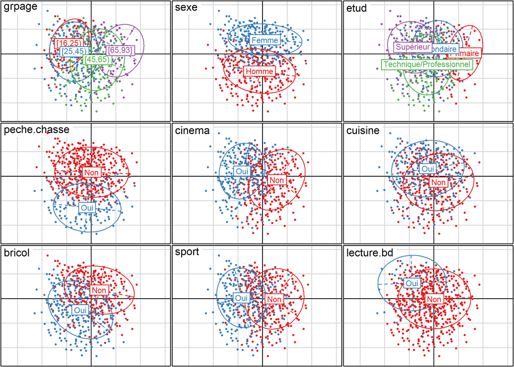

La fonction scatter appliquée au résultat d’une ACM

```r
scatter(acm, col = brewer.pal(4, "Set1"))
```

## ACM avec FactoMineR

Comme avec `ade4`, il est nécessaire de préparer les données au préalable (voir section précédente).

L’ACM se calcule avec la fonction `MCA`, l’argument `ncp` permettant de choisir le nombre d’axes à retenir :

```r
library(FactoMineR)
```

```r
acm2 <- MCA(d2, ncp = 5, graph = FALSE)
acm2
```

```
**Results of the Multiple Correspondence Analysis (MCA)**
The analysis was performed on 2000 individuals, described by 9 variables
*The results are available in the following objects:

   name              description
1  "$eig"            "eigenvalues"
2  "$var"            "results for the variables"
3  "$var$coord"      "coord. of the categories"
4  "$var$cos2"       "cos2 for the categories"
5  "$var$contrib"    "contributions of the categories"
6  "$var$v.test"     "v-test for the categories"
7  "$ind"            "results for the individuals"
8  "$ind$coord"      "coord. for the individuals"
9  "$ind$cos2"       "cos2 for the individuals"
10 "$ind$contrib"    "contributions of the individuals"
11 "$call"           "intermediate results"
12 "$call$marge.col" "weights of columns"
13 "$call$marge.li"  "weights of rows"
```

```r
acm2$eig
```

```
       eigenvalue percentage of variance
dim 1  0.25757489              15.454493
dim 2  0.18363502              11.018101
dim 3  0.16164626               9.698776
dim 4  0.12871623               7.722974
dim 5  0.12135737               7.281442
dim 6  0.11213331               6.727999
dim 7  0.10959377               6.575626
dim 8  0.10340564               6.204338
dim 9  0.09867478               5.920487
dim 10 0.09192693               5.515616
dim 11 0.07501208               4.500725
dim 12 0.06679676               4.007805
dim 13 0.06002063               3.601238
dim 14 0.05832024               3.499215
dim 15 0.03785276               2.271166
       cumulative percentage of variance
dim 1                           15.45449
dim 2                           26.47259
dim 3                           36.17137
dim 4                           43.89434
dim 5                           51.17579
dim 6                           57.90378
dim 7                           64.47941
dim 8                           70.68375
dim 9                           76.60424
dim 10                          82.11985
dim 11                          86.62058
dim 12                          90.62838
dim 13                          94.22962
dim 14                          97.72883
dim 15                         100.00000
```

```r
sum(acm2$eig[, 1])
```

```
[1] 1.666667
```

En premier lieu, il apparait que l’inertie totale obtenue avec `MCA` est différente de celle observée avec `dudi.acm`. Cela est dû à un traitement différents des valeurs manquantes. Alors que `dudi.acm` exclu les valeurs manquantes, `MCA` les considèrent, par défaut, comme une modalité additionnelle. Pour calculer l’ACM uniquement sur les individus n’ayant pas de valeur manquante, on aura recours à `complete.cases` :

```r
acm2 <- MCA(d2[complete.cases(d2), ], ncp = 5, graph = FALSE)
acm2$eig
```

```
       eigenvalue percentage of variance
dim 1  0.24790700              17.162792
dim 2  0.16758465              11.602014
dim 3  0.13042357               9.029324
dim 4  0.12595105               8.719688
dim 5  0.11338629               7.849820
dim 6  0.10976674               7.599236
dim 7  0.10060204               6.964757
dim 8  0.09802387               6.786268
dim 9  0.09283131               6.426783
dim 10 0.07673502               5.312425
dim 11 0.06609694               4.575942
dim 12 0.05950655               4.119684
dim 13 0.05562942               3.851267
       cumulative percentage of variance
dim 1                           17.16279
dim 2                           28.76481
dim 3                           37.79413
dim 4                           46.51382
dim 5                           54.36364
dim 6                           61.96287
dim 7                           68.92763
dim 8                           75.71390
dim 9                           82.14068
dim 10                          87.45311
dim 11                          92.02905
dim 12                          96.14873
dim 13                         100.00000
```

```r
sum(acm2$eig[, 1])
```

```
[1] 1.444444
```

Les possibilités graphiques de `FactoMineR` sont différentes de celles de `ade4`. Un recours à la fonction `plot` affichera par défaut les individus, les modalités et les variables. La commande `?plot.MCA` permet d’accéder au fichier d’aide de cette fonction (i.e. de la méthode générique `plot` appliquée aux objets de type `MCA`) et de voir toutes les options graphiques. L’argument `choix` permet de spécifier ce que l’on souhaite afficher (« ind » pour les individus et les catégories, « var » pour les variables). L’argument `invisible` quant à lui permet de spécifier ce que l’on souhaite masquer. Les axes à afficher se précisent avec `axes`. Voir les exemples ci-dessous.

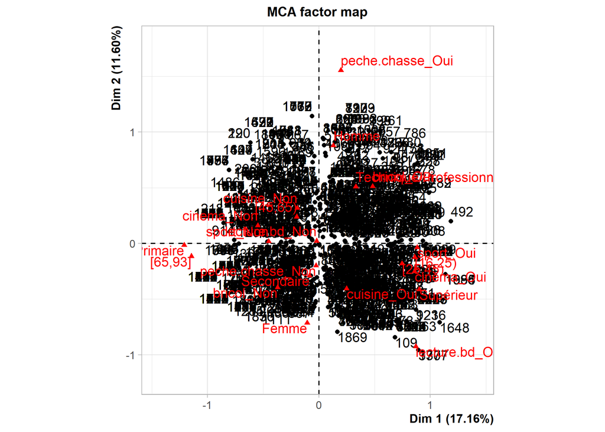

Plan factoriel (deux premiers axes)

```r
plot(acm2)
```

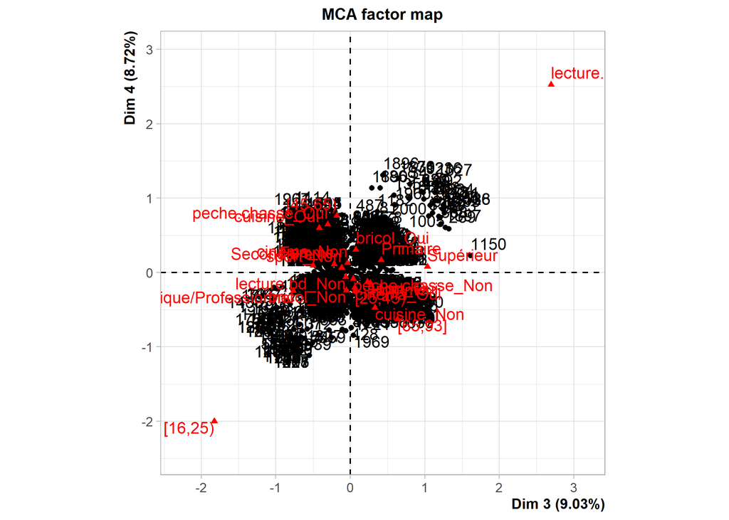

Plan factoriel (axes 3 et 4)

```r
plot(acm2, axes = c(3, 4))
```

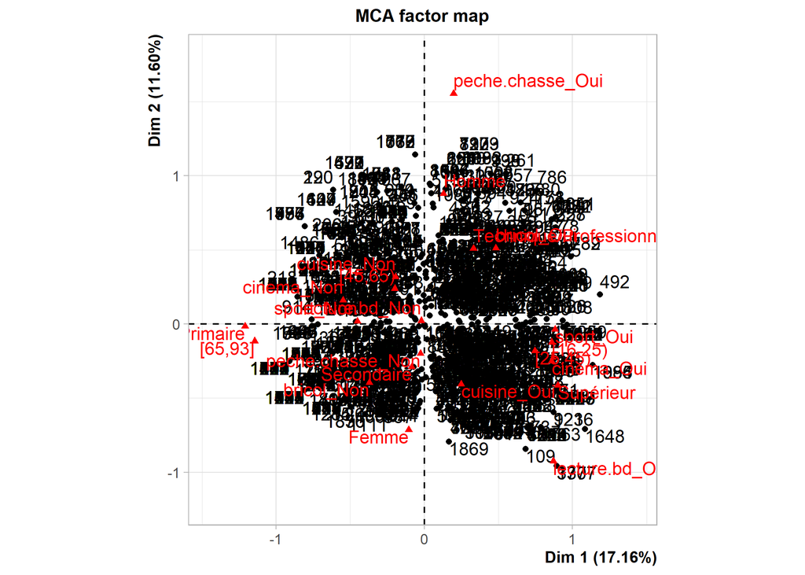

Plan factoriel (seulement les individus et les catégories)

```r
plot(acm2, choix = "ind")
```

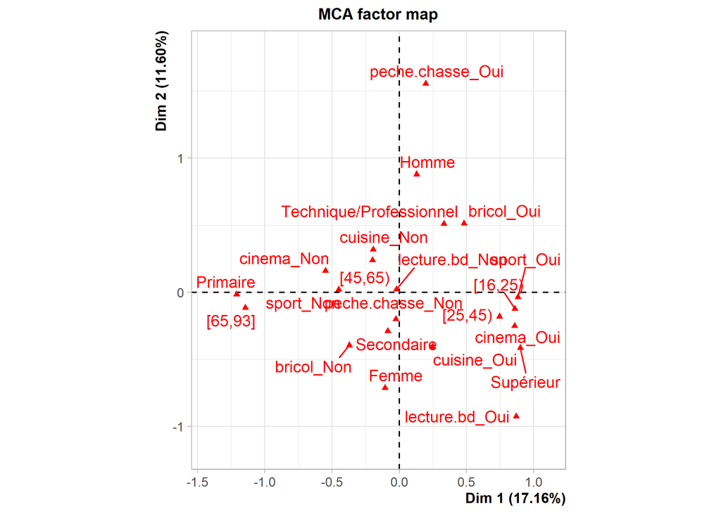

Plan factoriel (seulement les catégories)

```r
plot(acm2, choix = "ind", invisible = "ind")
```

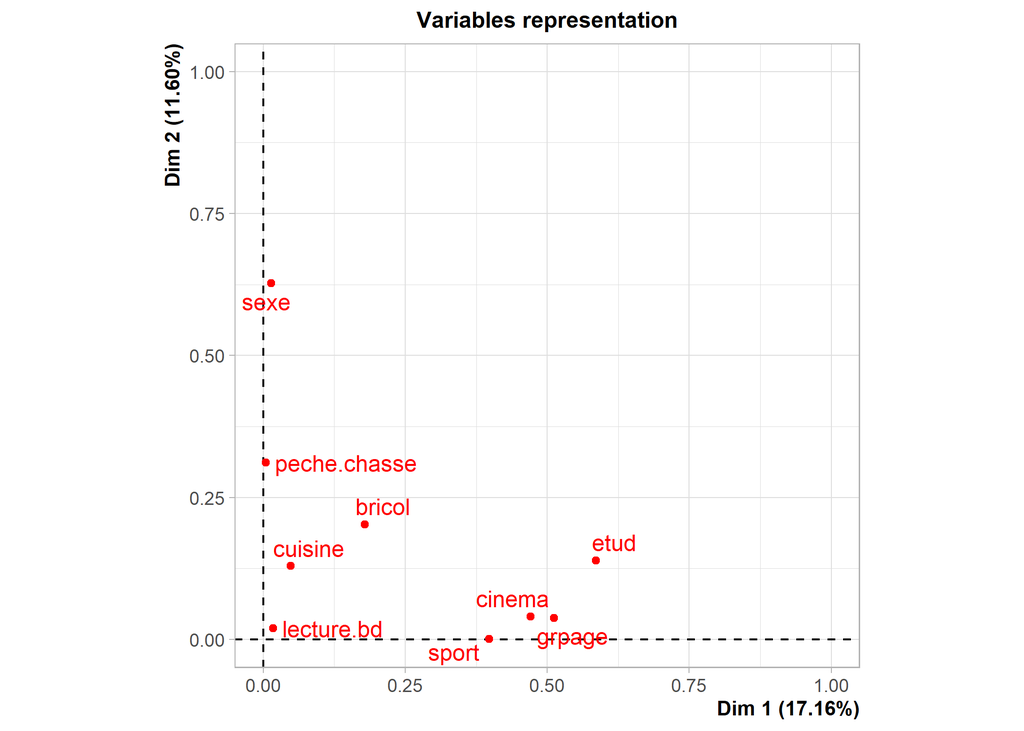

Plan factoriel (seulement les variables)

```r
plot(acm2, choix = "var")
```

La fonction `plotellipses` trace des ellipses de confiance atour des modalités de variables qualitatives. L’objectif est de voir si les modalités d’une variable qualitative sont significativement différentes les unes des autres.

Par défaut (`means=TRUE`), les ellipses de confiance sont calculées pour les coordonnées moyennes de chaque catégorie.

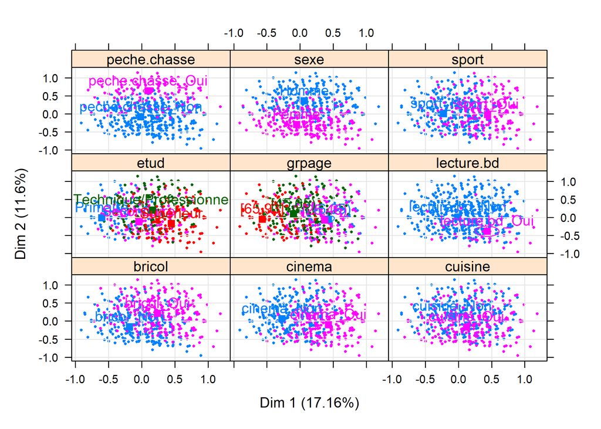

Ellipses de confiance (means=TRUE) dans le plan factoriel

```r
plotellipses(acm2)
```

L’option `means=FALSE` calculera les ellipses de confiance pour l’ensemble des coordonnées des observations relevant de chaque catégorie.

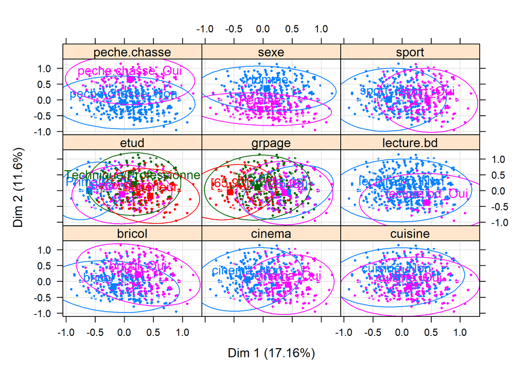

Ellipses de confiance (means=FALSE) dans le plan factoriel

```r
plotellipses(acm2, means = FALSE)
```

La fonction `dimdesc` aide à décrire et interpréter les dimensions de l’ACM. Cette fonction est très utile quand le nombre de variables est élevé. Elle permet de voir à quelles variables les axes sont le plus liés : quelles variables et quelles modalités décrivent le mieux chaque axe ?

> Pour les variables qualitatives, un modèle d’analyse de variance à un facteur est réalisé pour chaque dimension ; les variables à expliquer sont les coordonnées des individus et la variable explicative est une des variables qualitatives. Un test F permet de voir si la variable a un effet significatif sur la dimension et des tests T sont réalisés modalité par modalité (avec le contraste somme des alpha_i=0). Cela montre si les coordonnées des individus de la sous-population définie par une modalité sont significativement différentes de celles de l’ensemble de la population (*i.e.* différentes de 0). Les variables et modalités sont triées par probabilité critique et seules celles qui sont significatives sont gardées dans le résultat.

```r
dd <- dimdesc(acm2, axes = 1:2)
dd$`Dim 1`
```

[output not shown]

## Extensions complémentaires

### factoextra

L’extension `factoextra` fournit des fonctions graphiques `ggplot2` pour visualiser les résultats d’une analyse factorielle, réalisée avec `ade4` ou `FactoMineR`.

Plus d’informations sur https://rpkgs.datanovia.com/factoextra/.

### explor

L’extension `explor` fournit une interface graphique pour explorer les résultats d’une analyse factorielle, réalisée avec `ade4` ou `FactoMineR`.

[figure not shown]

Interface graphique de explor

Plus d’informations sur https://github.com/juba/explor/.

### GDAtools

L’extension `GDAtools` développé par Nicolas Robette propose plusieurs outils pour l’interprétation et la visualisation des analyses factorielles ainsi que différentes variables d’ACM, pour la prise en compte par exemple des valeurs manquantes.

On pourra se référer au tutoriel dédié disponible en français sur https://nicolas-robette.github.io/GDAtools/articles/french/Tutoriel_AGD.html.

### Factoshiny

L’extension `Factoshiny` permet d’améliorer facilement et de façon interactive les graphiques produits par `FactoMineR` pour les rendre beaucoup plus lisibles.

Plus d’informations sur http://factominer.free.fr/graphs/factoshiny-fr.html.

### FactoInvestigate

L’extension `FactoInvestigate` décrit et interprète automatiquement les résultats de votre analyse factorielle (ACP, AFC ou ACM) en choisissant les graphes les plus appropriés pour un rapport.

Vous avez juste à faire l’analyse comme habituellement avec `FactoMineR` ou `Factoshiny`, et ensuite utiliser `FactoInvestigate` pour obtenir un rapport automatisé.

Plus d’informations sur http://factominer.free.fr/reporting/index_fr.html.

## Voir aussi

Un tutoriel détaillé en français, Visualiser une analyse géométrique des données avec ggplot2 (R/RStudio), est disponible sur le blog Quanti : https://quanti.hypotheses.org/1871.

[^1]: Pour une présentation plus détaillée, voir  
    http://www.math.univ-toulouse.fr/~baccini/zpedago/asdm.pdf.
[^2]: La fonction `score` constituera également une aide à l’interprétation des axes.